# PRECOVID BIC QC report: RNA-seq

Christopher Jin using initial QC Report from BIC

Jan 2023

## The purpose of this QC report is to select for the samples that will be actively used in the Pre-COVID manuscript on sedentary adults.

# Main objectives

- 1. *PCA* of all samples for a given tissue, colored by batch, sex, clinical site, etc.
- 2. *Correlation Matrix*: correlate PCs with important QC metrics and study variables
- 3. Explore *Outliers and MOP-flagged samples*

# Load in the datasets

We loaded five datasets: 1) raw counts 2) pipeline QC metrics 3) wetlab QC metrics 4) phenotypic data and 5) blinded metadata.

```r
rna_seq_data = load_adu_data(repo_local_dir, rerun = T) #use the rna_common_functions
```

```
## Processing loading data
```

```
## The file /tmp/motrpac_human-precovid_t04-blood-rna_transcript-rna-seq_rsem-genes-count.txt already exists
```

```
## The file /tmp/motrpac_human-precovid_t06-muscle_transcript-rna-seq_rsem-genes-count.txt already exists
```

```
## The file /tmp/motrpac_human-precovid_t11-adipose_transcript-rna-seq_rsem-genes-count.txt already exists
```

```
## The file /labs/mpsnyder/cajin/repos/precovid-analyses/tmp//motrpac_human-precovid_transcript-rna-seq_qa-qc-metrics.csv already exists
```

```
## The file /labs/mpsnyder/cajin/repos/precovid-analyses/tmp//motrpac_adult_ds_extended_qc_redacted_v5.0.csv already exists
```

```
## The file /labs/mpsnyder/cajin/repos/precovid-analyses/tmp//motrpac_adult_dd_extended_qc_v5.0.csv already exists
```

```
## The file /labs/mpsnyder/cajin/repos/precovid-analyses/tmp//Redacted_ADULT_SED_DS_Key.csv already exists
```

```r
pheno_matrix = rna_seq_data$pheno_data
pheno_matrix = pheno_matrix[pheno_matrix$activity_level == 1,] #SED ONLY
pheno_matrix = pheno_matrix[pheno_matrix$pre_or_post_visit == 'ADU_BAS',] #PRESUSPENSION ONLY to visualize data
# pheno_matrix$randomGroupCode = droplevels(as.factor(pheno_matrix$randomGroupCode))

unique_pids = unique(pheno_matrix$participant_id)
pheno_matrix = pheno_matrix[match(unique_pids, pheno_matrix$participant_id),]
#we only want

temporal_groups = pheno_matrix$temporal_sampling_profile
age_groups = cut(pheno_matrix$age, breaks = c(18,35,50,65,80), labels=c('18-35','35-50','50-65','65-80')) #adding intended age groups
exercise_groups = pheno_matrix$randomGroupCode
sex_group = pheno_matrix$Sex

combinations = table(temporal_groups, age_groups, exercise_groups, sex_group) #function to actually make the table

combinations
```

```
## , , exercise_groups = ADUControl, sex_group = Female
##
##                age_groups
## temporal_groups 18-35 35-50 50-65 65-80
##          All        3     1     1     0
##          Early      2     4     3     0
##          Late       4     3     2     1
##          Middle     4     0     3     0
##
## , , exercise_groups = ADUEndur, sex_group = Female
##
##                age_groups
## temporal_groups 18-35 35-50 50-65 65-80
##          All        7     2     1     0
##          Early      3     4     5     0
##          Late       5     3     6     1
##          Middle     1     6     2     0
##
## , , exercise_groups = ADUResist, sex_group = Female
##
##                age_groups
## temporal_groups 18-35 35-50 50-65 65-80
##          All        4     7     1     1
##          Early      3     2     5     1
##          Late       7     2     5     0
##          Middle     7     2     1     0
##
## , , exercise_groups = ADUControl, sex_group = Male
##
##                age_groups
## temporal_groups 18-35 35-50 50-65 65-80
##          All        1     0     1     1
##          Early      1     0     0     0
##          Late       0     0     0     1
##          Middle     1     0     0     0
##
## , , exercise_groups = ADUEndur, sex_group = Male
##
##                age_groups
## temporal_groups 18-35 35-50 50-65 65-80
##          All        0     2     2     1
##          Early      4     0     0     0
##          Late       1     2     2     0
##          Middle     2     0     1     1
##
## , , exercise_groups = ADUResist, sex_group = Male
##
##                age_groups
## temporal_groups 18-35 35-50 50-65 65-80
##          All        2     1     2     0
##          Early      3     2     1     0
##          Late       1     2     2     0
##          Middle     5     2     1     0
```

# MOP-flagged samples

The RNA-seq pipeline manual of procedures (MOP) defines a flagged sample (e.g., potentially problematic) as a sample that satisfies one of the following: (1) number of read pairs $<20M$, (2) percent GC not in $[20,80]$, (3) percent rRNA reads $>20$, (4) percent of uniquely mapped reads $<60$, (5) RIN $<6$, and (6) percent coding reads + percent utr reads $< 50$. The function to flag the said samples are in `qc_report_aux_functions.R`

```r
#MOP-flagged samples:
rna_seq_data$rnaseq_meta$pipeline_flags =  rnaseq_pipeline_flagged_samples(rna_seq_data$rnaseq_meta)
rna_seq_data$rnaseq_meta$pipeline_flags[rna_seq_data$rnaseq_meta$pipeline_flags==''] <- 'No flags'
rna_seq_data$rnaseq_meta$mop_flagged = rna_seq_data$rnaseq_meta$pipeline_flags!='No flags'

#-----based on the analysis done on the RIN issue, especially in blood,
# we have decided to filter just the RIN < 5 samples, and keep samples between 5-6
#
mop_flagged_samples = rna_seq_data$rnaseq_meta %>%
  dplyr::filter(!pipeline_flags == "No flags") %>%
  dplyr::filter(!(RIN > 5 & pipeline_flags == "RIN<6")) %>%
  dplyr::select(vial_label,Tissue, pipeline_flags) %>%
  dplyr::mutate(pipeline_flags = ifelse(pipeline_flags == "RIN<6", "RIN<5", pipeline_flags))
head(mop_flagged_samples)
```

|  | vial_label | Tissue | pipeline_flags |
| --- | --- | --- | --- |
| 11062040401 | 11062040401 | PaxGene RNA | RIN<5 |
| 11322050401 | 11322050401 | PaxGene RNA | RIN<5 |
| 11283030401 | 11283030401 | PaxGene RNA | RIN<5 |
| 11278040401 | 11278040401 | PaxGene RNA | RIN<5 |
| 11088040401 | 11088040401 | PaxGene RNA | RIN<5 |
| 11062010401 | 11062010401 | PaxGene RNA | RIN<5 |

# Dataset normalization

We first remove unexpressed genes using the min_cpm and min_num_samples parameters. We then use edgeR for library size correction and for TMM normalization. For each dataset (i.e., tissue) we store the normalized data table and all additional variables (e.g., clinical data) in a list called norm_rnaseq_data. This normalization follows the same policy as the previous 1B material.

```r
min_cpm = 0.5
min_num_samples_pct = 0.1
norm_method="TMM"
# Specify how many PCs to examine
num_pcs = 5
num_pcs_for_outlier_analysis = 3
# Specify the significance level for association analysis
# (e.g., between a PC and a clinical variable) -> These are shown later down the report
p_thr = 0.0001
norm_rnaseq_data = list()
#this function also saves the normalization methodology into 'load_adu_norm' in the RNA helper library to avoid from re-running this normalization
for (tissue in tissues_analyzed) {
  unnorm_counts = rna_seq_data[[tissue]]
  curr_samples = as.character(colnames(unnorm_counts))
  norm_counts = edgeR_normalized_log_cpm(as.matrix(unnorm_counts),
                                         min_cpm = min_cpm,
                                         min_num_samples = round(length(unnorm_counts)*min_num_samples_pct),
                                         norm_method = norm_method
  )
  curr_meta1 = rna_seq_data$rnaseq_meta[curr_samples,]
  curr_meta2 = rna_seq_data$pheno_data[curr_samples,]
  curr_meta <- cbind(curr_meta1,curr_meta2)
  norm_rnaseq_data[[tissue]] = list(
    norm_counts = norm_counts,
    raw_counts = unnorm_counts[rownames(unnorm_counts) %in% rownames(norm_counts),],
    metadata = curr_meta)
}
```

# Examine the effect of the normalization process, which includes removing unexpressed genes. For each dataset show the boxplots of 20 randomly selected samples.

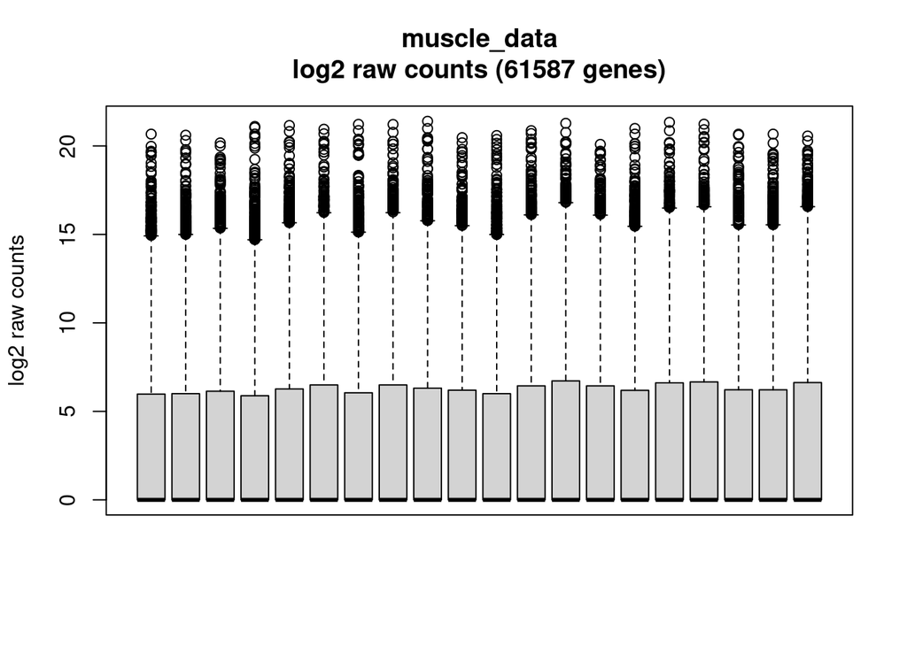

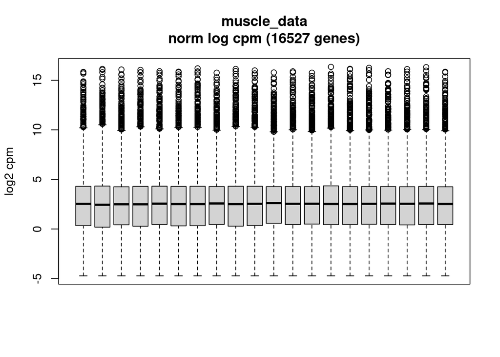

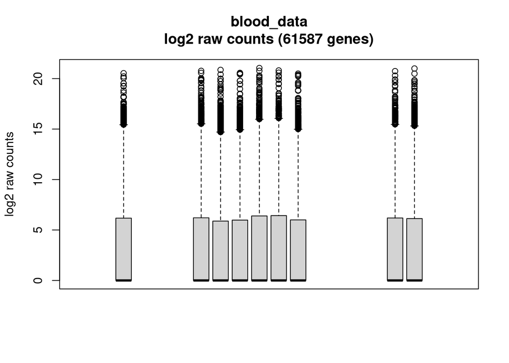

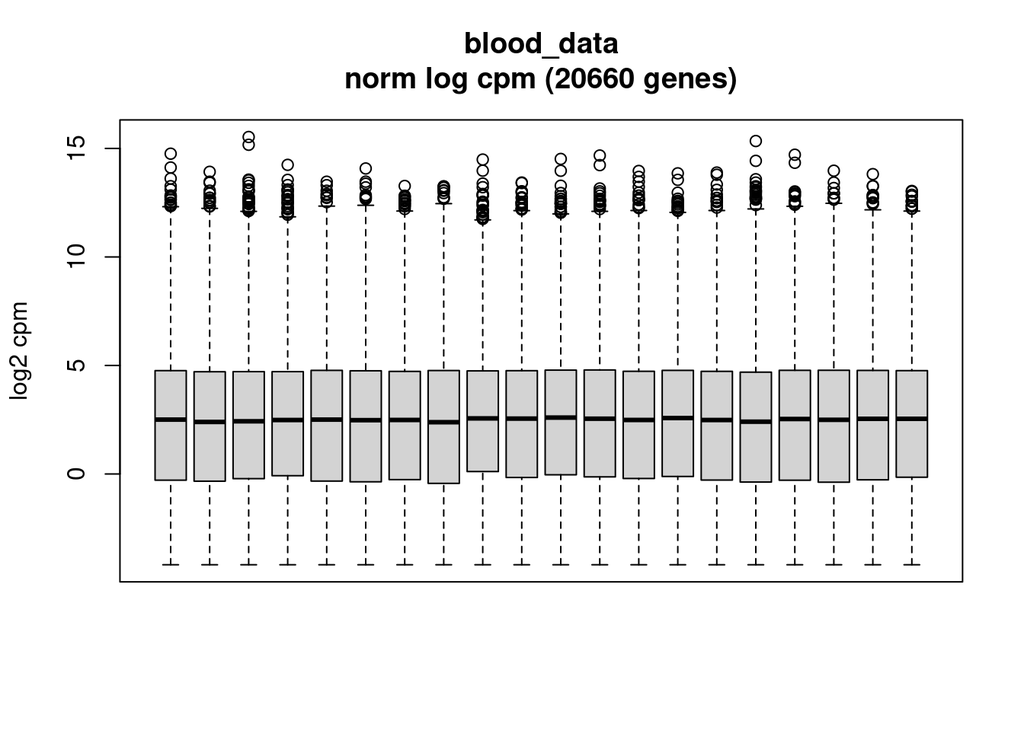

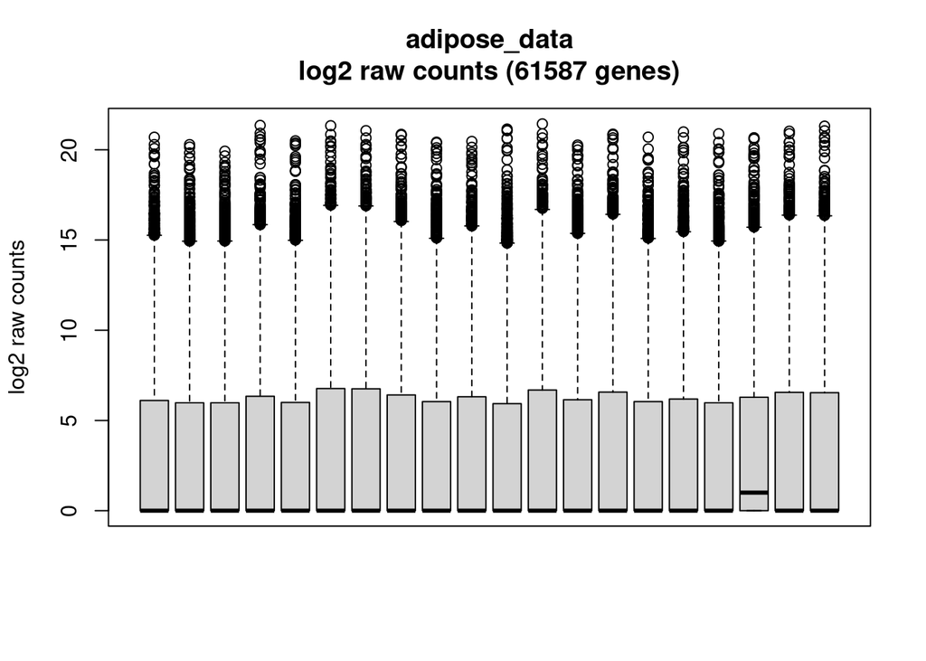

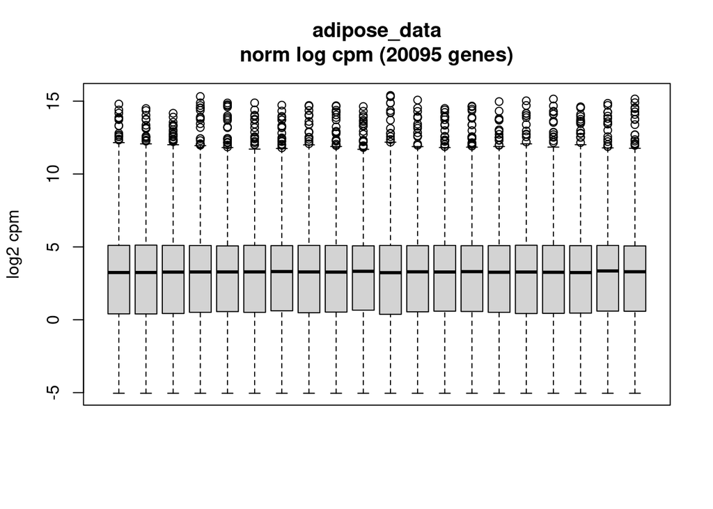

```r
for(i in 1:length(norm_rnaseq_data)){
  unnorm_data = rna_seq_data[[tissue]]
  norm_data = norm_rnaseq_data[[i]][["norm_counts"]]
  unnorm_data = log2(unnorm_data+1)
  samp = sample(1:ncol(norm_data))[1:20] #choose 20 genes from the random genes in the list
  curr_name = names(norm_rnaseq_data)[i]
  colnames(unnorm_data) = NULL
  colnames(norm_data) = NULL
  boxplot(unnorm_data[,samp],
          main=paste0(curr_name,"\nlog2 raw counts (",nrow(unnorm_counts)," genes)"),
          ylab = "log2 raw counts",xaxt="n")
  boxplot(norm_data[,samp],
          main=paste0(curr_name,"\nnorm log cpm (",nrow(norm_data)," genes)"),
          ylab = "log2 cpm",xaxt="n")
}
```

```r
#if there are 'empty/missing' genes (shown by no column), this means the gene is expressed in one of the tissues but not in that specific tissue
```

# PCA visualization

```r
for(currname in names(norm_rnaseq_data)){
  # run PCA
  print(currname)
  curr_data = norm_rnaseq_data[[currname]][["norm_counts"]]
  meta_pca = norm_rnaseq_data[[currname]]$metadata
  curr_pca = prcomp(t(curr_data),scale. = T,center = T)
  curr_pcax = curr_pca$x[,1:num_pcs]
  explained_var = summary(curr_pca)[["importance"]][2,c(1,2)]
  #adding loadings to find which genes are contributing the most to the PCs
  curr_loadings = curr_pca$rotation
  ranked_loadings = sort(abs(curr_loadings[,1]), decreasing = TRUE)
  norm_rnaseq_data[[currname]][["loadings"]] = ranked_loadings

  norm_rnaseq_data[[currname]][["pca"]] = curr_pcax
  norm_rnaseq_data[[currname]][["explained_var"]] = explained_var
  pca_outliers = c()
  for(j in 1:num_pcs_for_outlier_analysis){
    outlier_values <- boxplot.stats(curr_pcax[,j],coef = 5)$out
    for(outlier in names(outlier_values)){
      if(!is.element(outlier,names(pca_outliers))){
        pca_outliers[outlier] = outlier_values[outlier]
      }
    }
  }
  norm_rnaseq_data[[currname]]$metadata$pca_outliers <- ''
  norm_rnaseq_data[[currname]]$metadata$pca_outliers[rownames(norm_rnaseq_data[[currname]]$metadata) %in% names(pca_outliers)] <- 'PC outlier'
}
```

```
## [1] "muscle_data"
## [1] "blood_data"
## [1] "adipose_data"
```

Formatting of variables for PCA analysis

```r
muscle_pcas = cbind(norm_rnaseq_data[['muscle_data']]$pca,norm_rnaseq_data[['muscle_data']]$metadata)
blood_pcas = cbind(norm_rnaseq_data[['blood_data']]$pca,norm_rnaseq_data[['blood_data']]$metadata)
adipose_pcas = cbind(norm_rnaseq_data[['adipose_data']]$pca,norm_rnaseq_data[['adipose_data']]$metadata)
muscle_pcas$BID = NULL
blood_pcas$BID = NULL
adipose_pcas$BID = NULL
variables_pca = c('Age_3_groups','BMI_groups','Sex','pipeline_flags','pre_or_post_visit',
                  'Batch','clinical_site','Ethnicity','randomGroupCode','Timepoint_simplify')

muscle_pcas$clinical_site<-as.factor(muscle_pcas$clinical_site)
blood_pcas$clinical_site<-as.factor(blood_pcas$clinical_site)
adipose_pcas$clinical_site = as.factor(adipose_pcas$clinical_site)
```

Plotting of the batches randomization - By Sample

```r
library(stringr)
# muscle_pcas$
table_muscle1 <- table(muscle_pcas[,c('Batch','randomGroupCode')])
colnames(table_muscle1) <- paste(colnames(table_muscle1),'Intervention',sep=";")
table_muscle2 <- table(muscle_pcas[,c('Batch','Age_3_groups')])
colnames(table_muscle2) <- paste(colnames(table_muscle2),'Age',sep=";")
table_muscle3 <- table(muscle_pcas[,c('Batch','Sex')])
colnames(table_muscle3) <- paste(colnames(table_muscle3),'Sex',sep=";")
table_muscle4 <- table(muscle_pcas[,c('Batch','clinical_site')])
colnames(table_muscle4) <- paste(colnames(table_muscle4),'Clinical Site',sep=";")
table_muscle <- do.call("cbind",list(table_muscle1,table_muscle2,table_muscle3,table_muscle4))
table_muscle_melt <- melt(table_muscle)
table_muscle_melt$Var3 <- str_split(table_muscle_melt$Var2,pattern=';',simplify = T)[,1]
table_muscle_melt$Var4 <- str_split(table_muscle_melt$Var2,pattern=';',simplify = T)[,2]
```

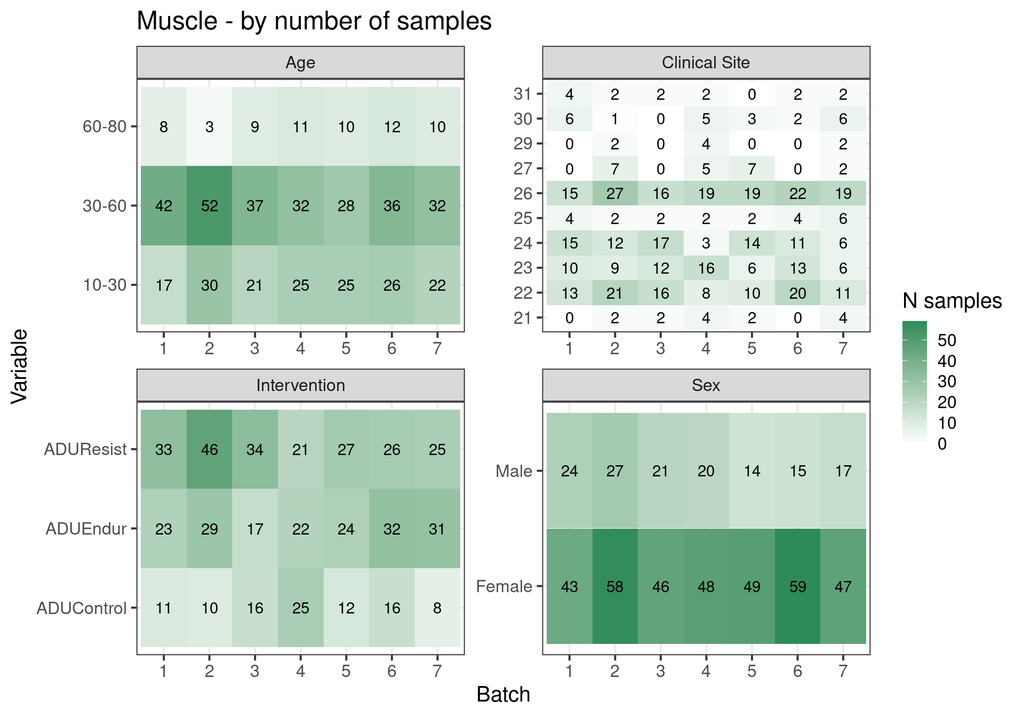

```r
table_muscle_melt$Var1 <- as.character(table_muscle_melt$Var1)
ggplot(data=table_muscle_melt, aes(x=Var1, y=Var3))+geom_tile(aes(fill = value))+facet_wrap(.~Var4, scales='free')+geom_text(aes(fill = table_muscle_melt$value, label = round(table_muscle_melt$value, 2)))+theme_bw(base_size = 15)+
  scale_fill_gradient2(low = "white",
                       high = "seagreen")+labs(title='Muscle - by number of samples', y='Variable',x='Batch', fill='N samples')
```

Plotting of the batches randomization - By Sample

```r
library(stringr)
table_muscle1 <- table(muscle_pcas[,c('Batch','randomGroupCode')])
colnames(table_muscle1) <- paste(colnames(table_muscle1),'Intervention',sep=";")
table_muscle2 <- table(muscle_pcas[,c('Batch','Age_3_groups')])
colnames(table_muscle2) <- paste(colnames(table_muscle2),'Age',sep=";")
table_muscle3 <- table(muscle_pcas[,c('Batch','Sex')])
colnames(table_muscle3) <- paste(colnames(table_muscle3),'Sex',sep=";")
table_muscle4 <- table(muscle_pcas[,c('Batch','clinical_site')])
colnames(table_muscle4) <- paste(colnames(table_muscle4),'Clinical Site',sep=";")
table_muscle <- do.call("cbind",list(table_muscle1,table_muscle2,table_muscle3,table_muscle4))
table_muscle_melt <- melt(table_muscle)
table_muscle_melt$Var3 <- str_split(table_muscle_melt$Var2,pattern=';',simplify = T)[,1]
table_muscle_melt$Var4 <- str_split(table_muscle_melt$Var2,pattern=';',simplify = T)[,2]
```

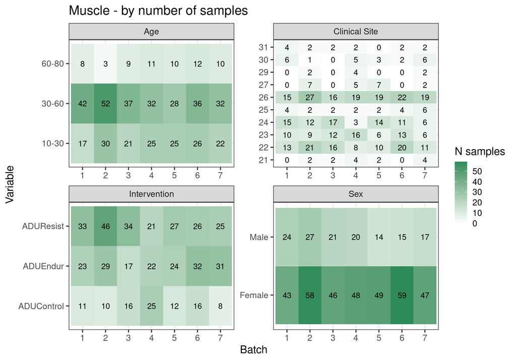

```r
table_muscle_melt$Var1 <- as.character(table_muscle_melt$Var1)
ggplot(data=table_muscle_melt, aes(x=Var1, y=Var3))+geom_tile(aes(fill = value))+facet_wrap(.~Var4, scales='free')+geom_text(aes(fill = table_muscle_melt$value, label = round(table_muscle_melt$value, 2)))+theme_bw(base_size = 15) +
  scale_fill_gradient2(low = "white",
                       high = "seagreen")+labs(title='Muscle - by number of samples', y='Variable',x='Batch', fill='N samples')
```

```r
table_muscle1 <- table(muscle_pcas[,c('Timepoint','randomGroupCode')])
table_muscle_melt <- melt(table_muscle1)
```

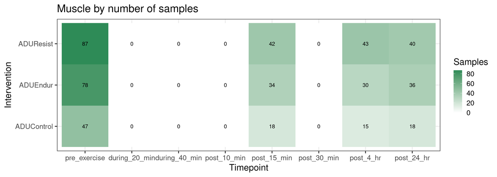

```r
ggplot(data=table_muscle_melt[table_muscle_melt$randomGroupCode%in%c("ADUControl","ADUEndur","ADUResist"),], aes(x=Timepoint, y=randomGroupCode))+geom_tile(aes(fill = value))+
  geom_text(data=table_muscle_melt[table_muscle_melt$randomGroupCode%in%c("ADUControl","ADUEndur","ADUResist"),],aes(fill = value, label = value))+
  theme_bw(base_size = 18)+#+theme(text = element_text(size = 30))+
  scale_fill_gradient2(low = "white",
                       high = "seagreen")+labs(y='Intervention',fill='Samples',title='Muscle by number of samples ')
```

Do the same, but for Sex

```r
library(stringr)
table_muscle1 <- table(muscle_pcas[,c('Sex','randomGroupCode')])
colnames(table_muscle1) <- paste(colnames(table_muscle1),'Intervention',sep=";")
table_muscle2 <- table(muscle_pcas[,c('Sex','Age_3_groups')])
colnames(table_muscle2) <- paste(colnames(table_muscle2),'Age',sep=";")
table_muscle3 <- table(muscle_pcas[,c('Sex','clinical_site')])
colnames(table_muscle3) <- paste(colnames(table_muscle3),'Clinical Site',sep=";")
table_muscle4 <- table(muscle_pcas[,c('Sex','temporal_sampling_profile')])
colnames(table_muscle4) <- paste(colnames(table_muscle4),'temporal_sampling_profile',sep=";")
table_muscle <- do.call("cbind",list(table_muscle1,table_muscle2,table_muscle3,table_muscle4))
table_muscle_melt <- melt(table_muscle)
table_muscle_melt$Var3 <- str_split(table_muscle_melt$Var2,pattern=';',simplify = T)[,1]
table_muscle_melt$Var4 <- str_split(table_muscle_melt$Var2,pattern=';',simplify = T)[,2]
```

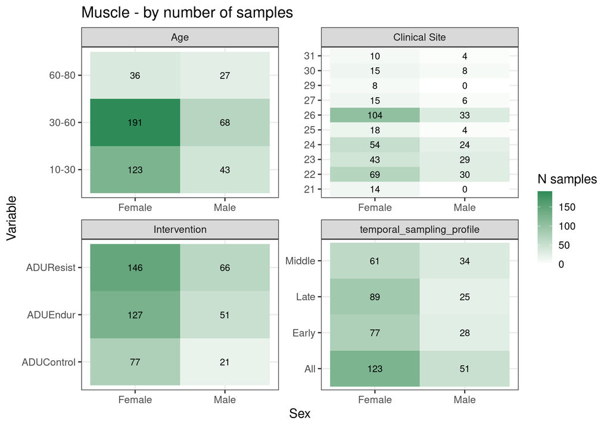

```r
table_muscle_melt$Var1 <- as.character(table_muscle_melt$Var1)
ggplot(data=table_muscle_melt, aes(x=Var1, y=Var3))+geom_tile(aes(fill = value))+facet_wrap(.~Var4, scales='free')+geom_text(aes(fill = table_muscle_melt$value, label = round(table_muscle_melt$value, 2)))+theme_bw(base_size = 15)+#+theme(text = element_text(size = 30))+
  scale_fill_gradient2(low = "white",
                       high = "seagreen")+labs(title='Muscle - by number of samples', y='Variable',x='Sex', fill='N samples')
```

```r
table_muscle1 <- table(blood_pcas[,c('Timepoint','randomGroupCode')])
table_muscle_melt <- melt(table_muscle1)
```

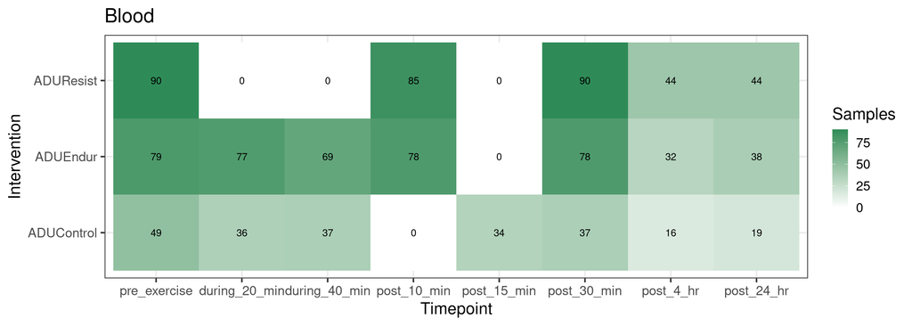

```r
ggplot(data=table_muscle_melt[table_muscle_melt$randomGroupCode%in%c("ADUControl","ADUEndur","ADUResist"),], aes(x=Timepoint, y=randomGroupCode))+geom_tile(aes(fill = value))+
  geom_text(data=table_muscle_melt[table_muscle_melt$randomGroupCode%in%c("ADUControl","ADUEndur","ADUResist"),],aes(fill = value, label = value))+
  theme_bw(base_size = 18)+#+theme(text = element_text(size = 30))+
  scale_fill_gradient2(low = "white",
                       high = "seagreen")+labs(y='Intervention',fill='Samples',title='Blood')
```

Repeat, for blood

```r
library(stringr)
table_blood1 <- table(blood_pcas[,c('Batch','randomGroupCode')])
colnames(table_blood1) <- paste(colnames(table_blood1),'Intervention',sep=";")
table_blood2 <- table(blood_pcas[,c('Batch','Age_3_groups')])
colnames(table_blood2) <- paste(colnames(table_blood2),'Age',sep=";")
table_blood3 <- table(blood_pcas[,c('Batch','Sex')])
colnames(table_blood3) <- paste(colnames(table_blood3),'Sex',sep=";")
table_blood4 <- table(blood_pcas[,c('Batch','clinical_site')])
colnames(table_blood4) <- paste(colnames(table_blood4),'Clinical Site',sep=";")
table_blood <- do.call("cbind",list(table_blood1,table_blood2,table_blood3,table_blood4))
table_blood_melt <- melt(table_blood)
table_blood_melt$Var1 <- factor(table_blood_melt$Var1, levels=c(1:15))
table_blood_melt$Var3 <- str_split(table_blood_melt$Var2,pattern=';',simplify = T)[,1]
table_blood_melt$Var4 <- str_split(table_blood_melt$Var2,pattern=';',simplify = T)[,2]
```

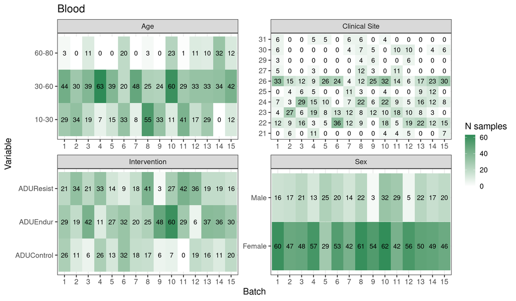

```r
ggplot(data=table_blood_melt, aes(x=Var1, y=Var3))+geom_tile(aes(fill = value))+facet_wrap(.~Var4, scales='free')+geom_text(aes(fill = table_blood_melt$value, label = round(table_blood_melt$value, 2)))+
  scale_fill_gradient2(low = "white",
                       high = "seagreen")+theme_bw(base_size=15)+labs(title='Blood', y='Variable',x='Batch', fill='N samples')
```

And again, for adipose. Honestly not very efficient code…but it is what it is.

```r
library(stringr)
table_adipose1 <- table(adipose_pcas[,c('Batch','randomGroupCode')])
colnames(table_adipose1) <- paste(colnames(table_adipose1),'Intervention',sep=";")
table_adipose2 <- table(adipose_pcas[,c('Batch','Age_3_groups')])
colnames(table_adipose2) <- paste(colnames(table_adipose2),'Age',sep=";")
table_adipose3 <- table(adipose_pcas[,c('Batch','Sex')])
colnames(table_adipose3) <- paste(colnames(table_adipose3),'Sex',sep=";")
table_adipose4 <- table(adipose_pcas[,c('Batch','clinical_site')])
colnames(table_adipose4) <- paste(colnames(table_adipose4),'Clinical Site',sep=";")
table_adipose <- do.call("cbind",list(table_adipose1,table_adipose2,table_adipose3,table_adipose4))
table_adipose_melt <- melt(table_adipose)
table_adipose_melt$Var1 <- factor(table_adipose_melt$Var1)
table_adipose_melt$Var3 <- str_split(table_adipose_melt$Var2,pattern=';',simplify = T)[,1]
table_adipose_melt$Var4 <- str_split(table_adipose_melt$Var2,pattern=';',simplify = T)[,2]
```

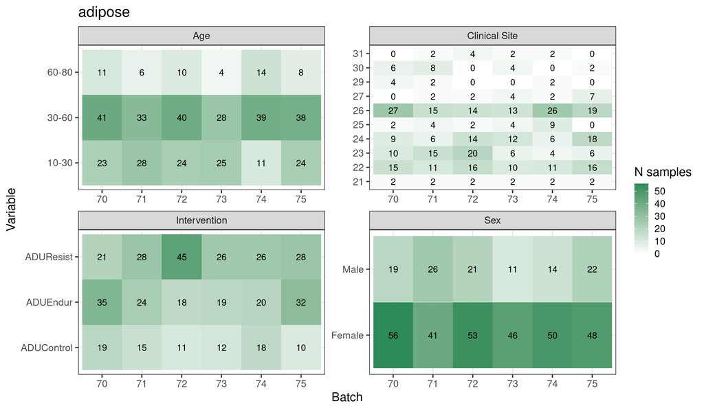

```r
ggplot(data=table_adipose_melt, aes(x=Var1, y=Var3))+geom_tile(aes(fill = value))+facet_wrap(.~Var4, scales='free')+geom_text(aes(fill = table_adipose_melt$value, label = round(table_adipose_melt$value, 2)))+
  scale_fill_gradient2(low = "white",
                       high = "seagreen")+theme_bw(base_size=15)+labs(title='adipose', y='Variable',x='Batch', fill='N samples')
```

```r
table_adipose1 <- table(adipose_pcas[,c('Timepoint','randomGroupCode')])
table_adipose_melt <- melt(table_adipose1)
```

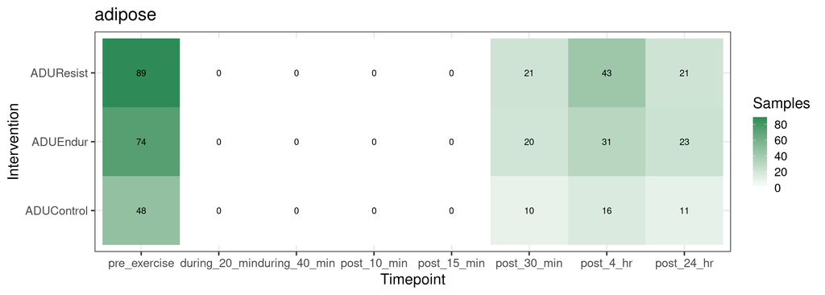

```r
ggplot(data=table_adipose_melt[table_adipose_melt$randomGroupCode%in%c("ADUControl","ADUEndur","ADUResist"),], aes(x=Timepoint, y=randomGroupCode))+geom_tile(aes(fill = value))+
  geom_text(data=table_adipose_melt[table_adipose_melt$randomGroupCode%in%c("ADUControl","ADUEndur","ADUResist"),],aes(fill = value, label = value))+
  theme_bw(base_size = 18)+#+theme(text = element_text(size = 30))+
  scale_fill_gradient2(low = "white",
                       high = "seagreen")+labs(y='Intervention',fill='Samples',title='adipose')
```

Here we merge all the counts matrixes by shared genes and do a shared PCA to see general dimensional reduction across the datasets

```r
muscle_pcas$Tissue <- 'Muscle'
blood_pcas$Tissue <- 'Blood'
adipose_pcas$Tissue = 'Adipose'
all_datasets <- rbind(muscle_pcas,blood_pcas, adipose_pcas)
```

Visualization of RIN distribution in blood, highlighting some technical issues that came up in processing. a section of the samples in blood had lower quality RNA

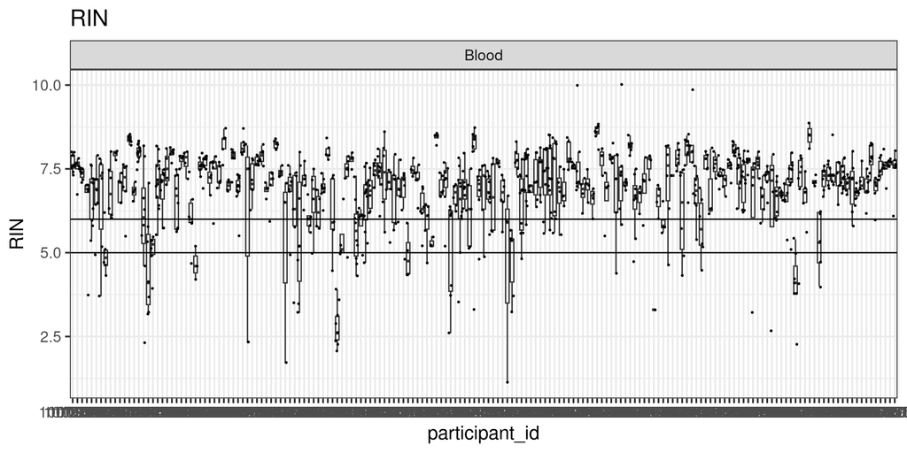

```r
variables_boxplot = c('RIN')
list_box = list()
for (var in variables_boxplot) {
  list_box[[var]] <- ggplot(data=blood_pcas,aes_string(x='participant_id',y=var))+geom_boxplot(outlier.shape=NA)+facet_wrap(.~Tissue,scales='free_x')+geom_jitter(color="black", size=0.4, alpha=0.9)+
    geom_hline(yintercept = 6.0) +
    geom_hline(yintercept = 5.0) +
    theme_bw(base_size = 15)+labs(title=var,y='RIN')

}
ggpubr::ggarrange(plotlist=list_box, nrow=1,ncol=1)
```

RIN in muscle data–clearly not an issue, all samples are extremely high quality.

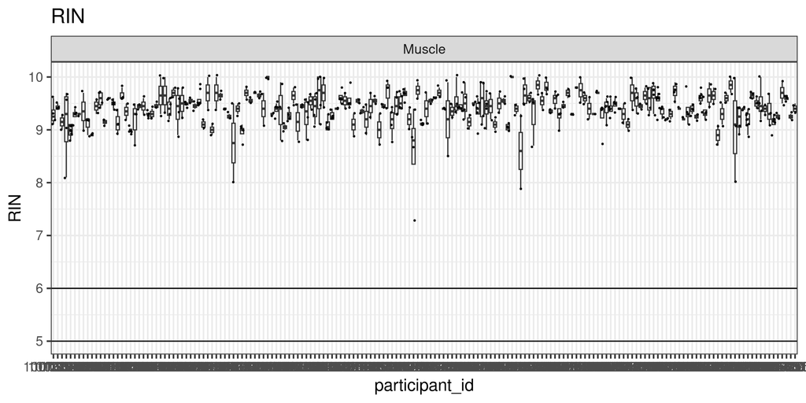

```r
variables_boxplot = c('RIN')
list_box = list()
for (var in variables_boxplot) {
  list_box[[var]] <- ggplot(data=muscle_pcas,aes_string(x='participant_id',y=var))+geom_boxplot(outlier.shape=NA)+facet_wrap(.~Tissue,scales='free_x')+geom_jitter(color="black", size=0.4, alpha=0.9)+
    geom_hline(yintercept = 6.0) +
    geom_hline(yintercept = 5.0) +
    theme_bw(base_size = 15)+labs(title=var,y='RIN')

}
ggpubr::ggarrange(plotlist=list_box, nrow=1,ncol=1)
```

Distribution of “high importance” qc metrics used in RNA-seq across all datasets.

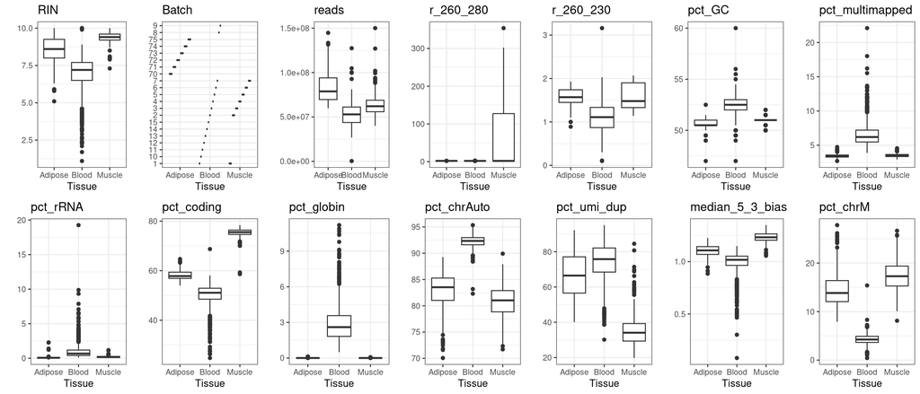

```r
variables_boxplot = c('RIN','Batch','reads','r_260_280','r_260_230','pct_GC','pct_multimapped','pct_rRNA','pct_coding','pct_globin','pct_chrAuto','pct_umi_dup','median_5_3_bias','pct_chrM')
list_box = list()
for (var in variables_boxplot) {
  list_box[[var]] <- ggplot(data=all_datasets,aes_string(x='Tissue',y=var))+geom_boxplot()+
    theme_bw()+labs(title=var,y='')

}
ggpubr::ggarrange(plotlist=list_box, nrow=2,ncol=7)
```

Muscle PCs by different dimensions

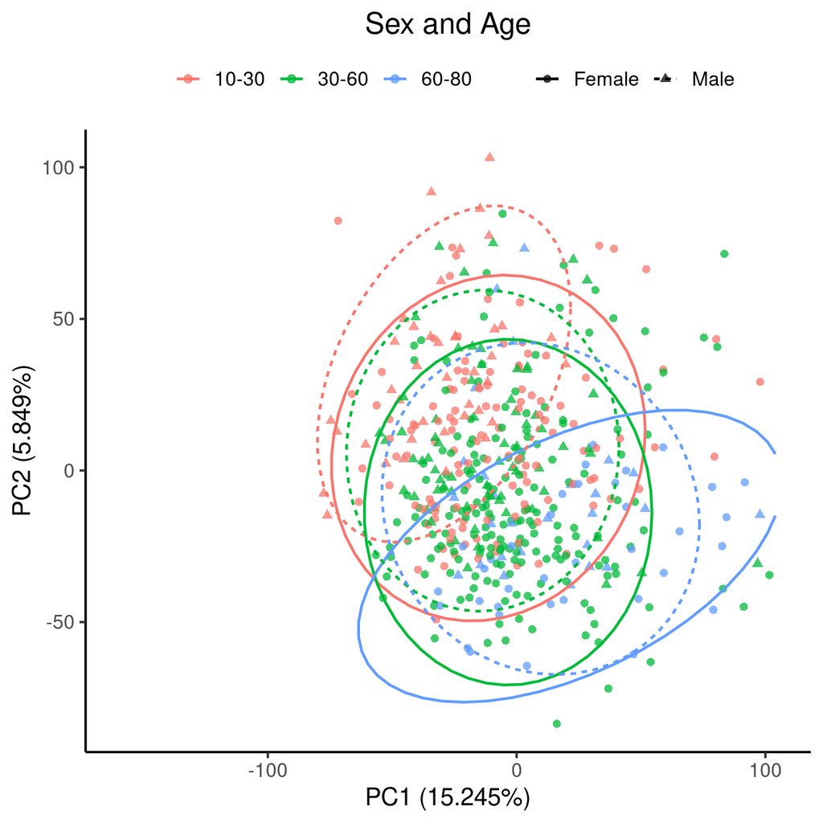

```r
var <- 'Age_3_groups'
var_exp <- norm_rnaseq_data[['muscle_data']][["explained_var"]]*100
ggplot(data=muscle_pcas,aes_string(x='PC1',y='PC2',color=var,shape='Sex'))+
  geom_point(size=2,alpha=0.75)+
  stat_ellipse(size=0.8,type = 't',aes(lty=Sex))+
  xlim(c(-160,105))+
  guides(color=guide_legend(nrow=1,byrow=TRUE))+
  theme_classic(base_size = 15)+labs(color=var,title='Sex and Age',x=paste('PC1 ','(',var_exp[1],'%)',sep=''),y=paste('PC2 ','(',var_exp[2],'%)',sep=''))+
  theme(legend.position="top",legend.title=element_blank(),plot.title = element_text(hjust = 0.5))
```

Muscle PCs by different dimensions

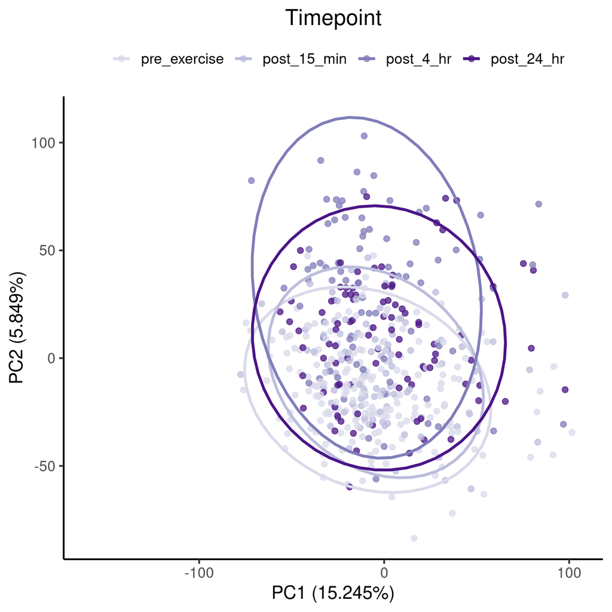

```r
var <- 'Timepoint'
var_exp <- norm_rnaseq_data[['muscle_data']][["explained_var"]]*100
ggplot(data=muscle_pcas,aes_string(x='PC1',y='PC2',color=var))+
  geom_point(size=2,alpha=0.75)+
  stat_ellipse(size=1.1,type = 't')+
  xlim(c(-160,105))+
  scale_color_manual(values=colorRampPalette(brewer.pal(n = 8, name = "Purples")[c(3,4,6,8)])(4))+
  #scale_color_brewer(palette="Spectral")+
  guides(color=guide_legend(nrow=1,byrow=TRUE))+
  theme_classic(base_size = 15)+labs(color=var,title='Timepoint',x=paste('PC1 ','(',var_exp[1],'%)',sep=''),y=paste('PC2 ','(',var_exp[2],'%)',sep=''))+
  theme(legend.position="top",legend.title=element_blank(),plot.title = element_text(hjust = 0.5))
```

## PCA for Blood RIN

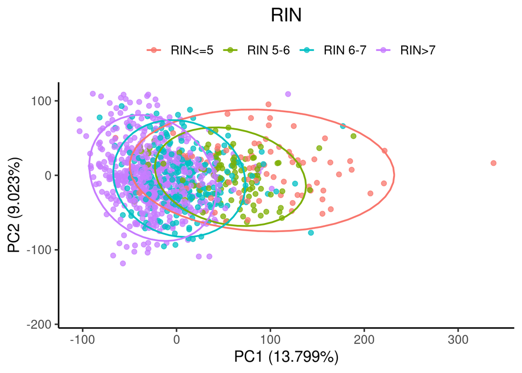

```r
var <- 'RIN5'
var_exp <- norm_rnaseq_data[['blood_data']][["explained_var"]]*100
#blood_pcas$RIN5 <- cut(blood_pcas$RIN,c(0,6,20),labels=c('RIN<=6','RIN>6'))
blood_pcas$RIN5 <- cut(blood_pcas$RIN,c(0,5,6,7,20),labels=c('RIN<=5','RIN 5-6','RIN 6-7','RIN>7'))
ggplot(data=blood_pcas[!is.na(blood_pcas$RIN),],aes_string(x='PC1',y='PC2',color=var))+
  geom_point(size=2,alpha=0.75)+
  stat_ellipse(size=0.8,type = 't')+
  ylim(c(-190,110))+
  guides(color=guide_legend(nrow=1,byrow=TRUE))+
  theme_classic(base_size = 15)+labs(color=var,title='RIN',x=paste('PC1 ','(',var_exp[1],'%)',sep=''),y=paste('PC2 ','(',var_exp[2],'%)',sep=''))+
  theme(legend.position="top",legend.title=element_blank(),plot.title = element_text(hjust = 0.5))
```

Blood PCs by different dimensions

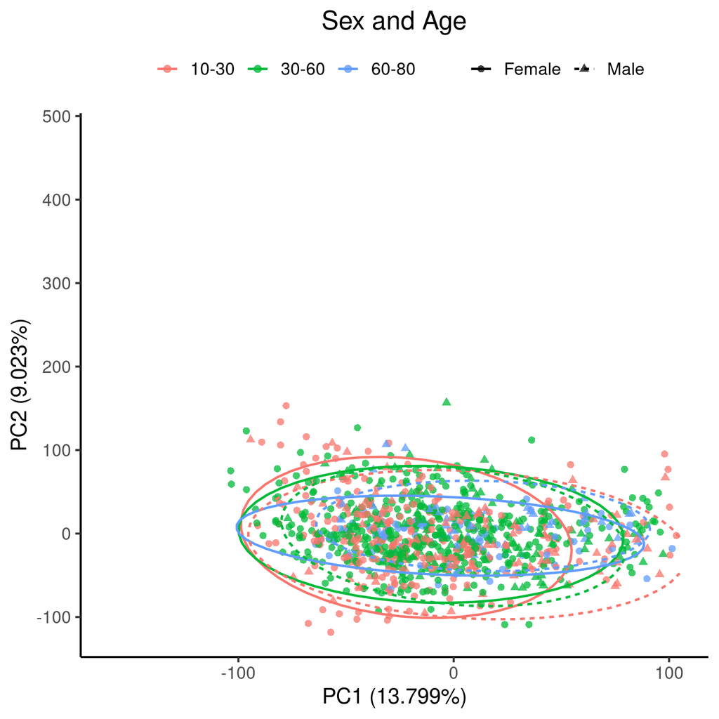

```r
var <- 'Age_3_groups'
var_exp <- norm_rnaseq_data[['blood_data']][["explained_var"]]*100
ggplot(data=blood_pcas,aes_string(x='PC1',y='PC2',color=var,shape='Sex'))+
  geom_point(size=2,alpha=0.75)+
  stat_ellipse(size=0.8,type = 't',aes(lty=Sex))+
  xlim(c(-160,105))+
  guides(color=guide_legend(nrow=1,byrow=TRUE))+
  theme_classic(base_size = 15)+labs(color=var,title='Sex and Age',x=paste('PC1 ','(',var_exp[1],'%)',sep=''),y=paste('PC2 ','(',var_exp[2],'%)',sep=''))+
  theme(legend.position="top",legend.title=element_blank(),plot.title = element_text(hjust = 0.5))
```

Adipose PCs by different dimensions

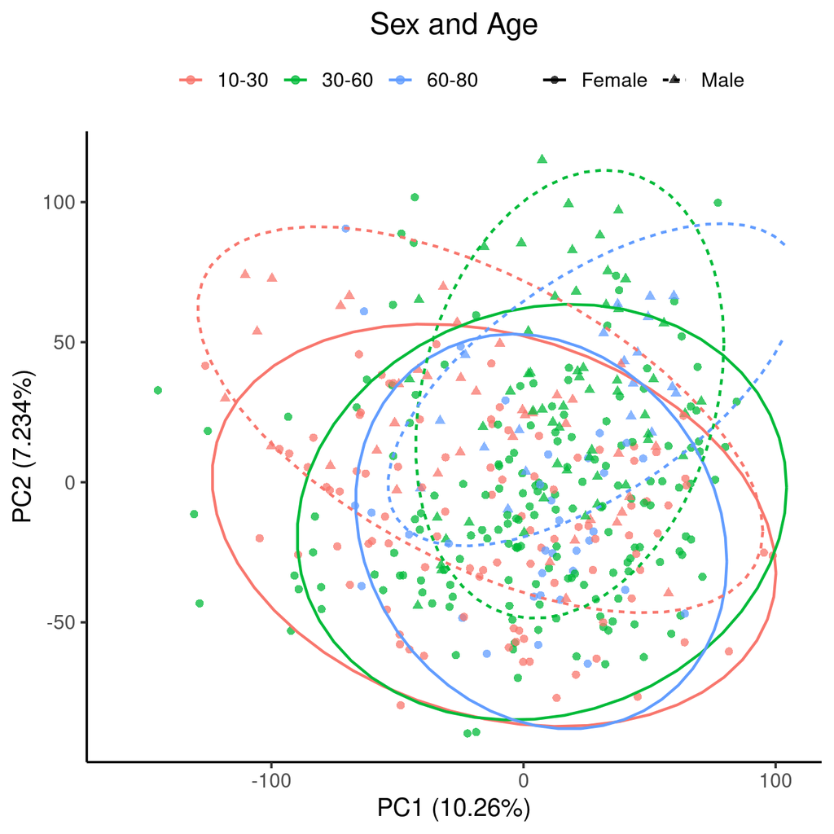

```r
var <- 'Age_3_groups'
var_exp <- norm_rnaseq_data[['adipose_data']][["explained_var"]]*100
ggplot(data=adipose_pcas,aes_string(x='PC1',y='PC2',color=var,shape='Sex'))+
  geom_point(size=2,alpha=0.75)+
  stat_ellipse(size=0.8,type = 't',aes(lty=Sex))+
  xlim(c(-160,105))+
  guides(color=guide_legend(nrow=1,byrow=TRUE))+
  theme_classic(base_size = 15)+labs(color=var,title='Sex and Age',x=paste('PC1 ','(',var_exp[1],'%)',sep=''),y=paste('PC2 ','(',var_exp[2],'%)',sep=''))+
  theme(legend.position="top",legend.title=element_blank(),plot.title = element_text(hjust = 0.5))
```

Adipose PCs by different dimensions

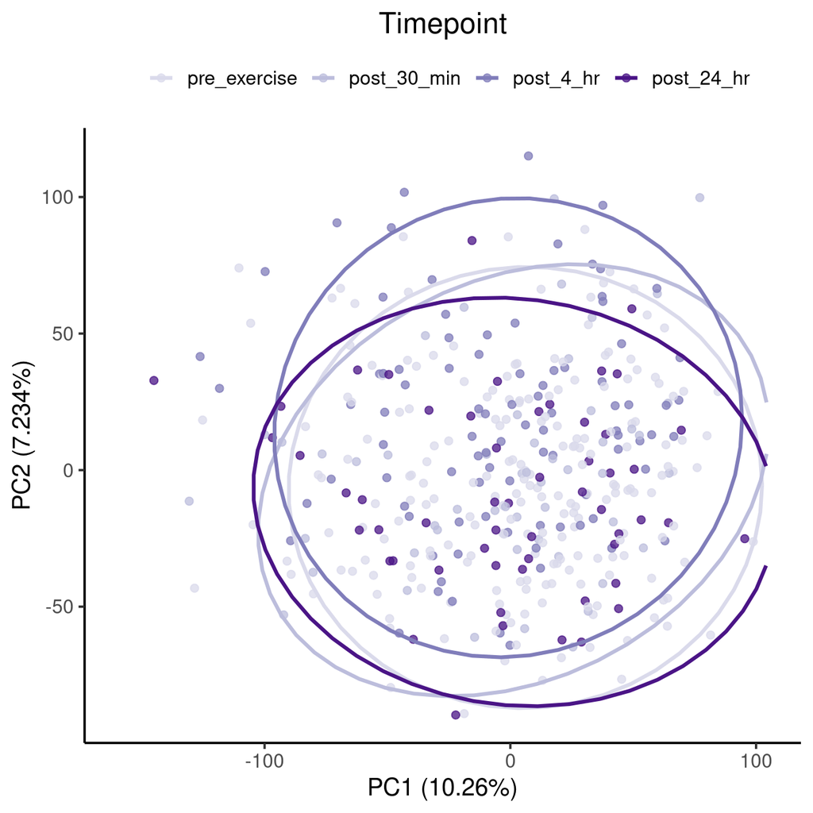

```r
var <- 'Timepoint'
var_exp <- norm_rnaseq_data[['adipose_data']][["explained_var"]]*100
ggplot(data=adipose_pcas,aes_string(x='PC1',y='PC2',color=var))+
  geom_point(size=2,alpha=0.75)+
  stat_ellipse(size=1.1,type = 't')+
  xlim(c(-160,105))+
  scale_color_manual(values=colorRampPalette(brewer.pal(n = 8, name = "Purples")[c(3,4,6,8)])(4))+
  #scale_color_brewer(palette="Spectral")+
  guides(color=guide_legend(nrow=1,byrow=TRUE))+
  theme_classic(base_size = 15)+labs(color=var,title='Timepoint',x=paste('PC1 ','(',var_exp[1],'%)',sep=''),y=paste('PC2 ','(',var_exp[2],'%)',sep=''))+
  theme(legend.position="top",legend.title=element_blank(),plot.title = element_text(hjust = 0.5))
```

## PCA based on input RNA for blood

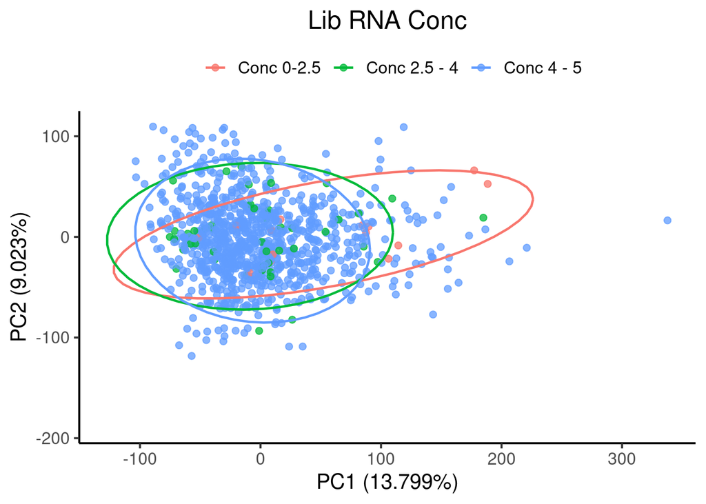

```r
var <- 'Lib_RNA_conc'
var_exp <- norm_rnaseq_data[['blood_data']][["explained_var"]]*100
blood_pcas$Lib_RNA_conc <- cut(blood_pcas$Lib_RNA_conc, c(0,2.5,4,5),labels=c('Conc 0-2.5','Conc 2.5 - 4','Conc 4 - 5'))
ggplot(data=blood_pcas[!is.na(blood_pcas$Lib_RNA_conc),],aes_string(x='PC1',y='PC2',color=var))+
  geom_point(size=2,alpha=0.75)+
  stat_ellipse(size=0.8,type = 't')+
  ylim(c(-190,110))+
  guides(color=guide_legend(nrow=1,byrow=TRUE))+
  theme_classic(base_size = 15)+labs(color=var,title='Lib RNA Conc',x=paste('PC1 ','(',var_exp[1],'%)',sep=''),y=paste('PC2 ','(',var_exp[2],'%)',sep=''))+
  theme(legend.position="top",legend.title=element_blank(),plot.title = element_text(hjust = 0.5))
```

## PCA based on input RNA for muscle

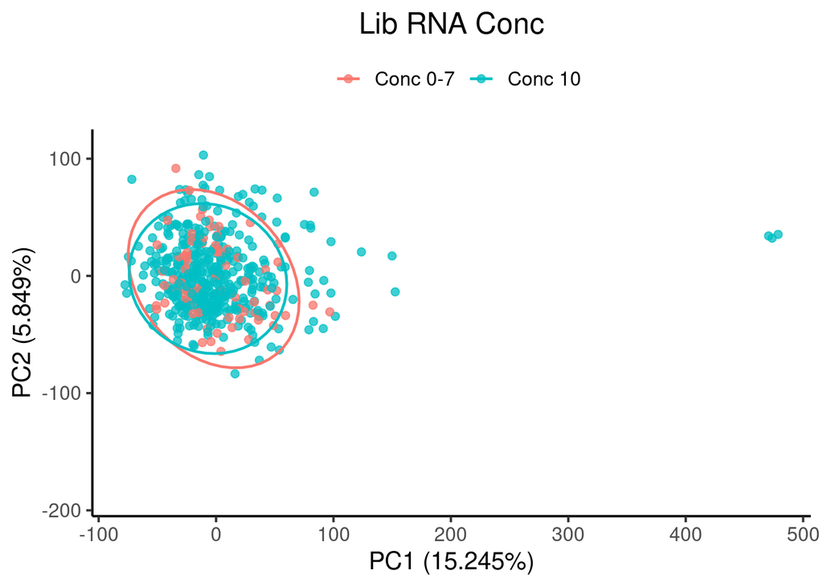

```r
var <- 'Lib_RNA_conc'
var_exp <- norm_rnaseq_data[['muscle_data']][["explained_var"]]*100
muscle_pcas$Lib_RNA_conc <- cut(muscle_pcas$Lib_RNA_conc, c(0,7,10),labels=c('Conc 0-7','Conc 10'))
ggplot(data=muscle_pcas[!is.na(muscle_pcas$Lib_RNA_conc),],aes_string(x='PC1',y='PC2',color=var))+
  geom_point(size=2,alpha=0.75)+
  stat_ellipse(size=0.8,type = 't')+
  ylim(c(-190,110))+
  guides(color=guide_legend(nrow=1,byrow=TRUE))+
  theme_classic(base_size = 15)+labs(color=var,title='Lib RNA Conc',x=paste('PC1 ','(',var_exp[1],'%)',sep=''),y=paste('PC2 ','(',var_exp[2],'%)',sep=''))+
  theme(legend.position="top",legend.title=element_blank(),plot.title = element_text(hjust = 0.5))
```

Checking to see if number of amplification shows up in PCA space

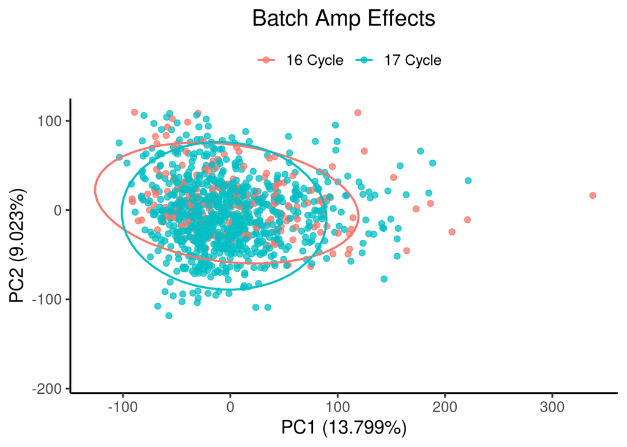

```r
var <- 'Amp_Cycle'
var_exp <- norm_rnaseq_data[['blood_data']][["explained_var"]]*100

#Batch number treated as "factor" not numeric
blood_pcas$Amp_Cycle <- sapply(blood_pcas$Batch, as.numeric)
blood_pcas$Amp_Cycle <- cut(blood_pcas$Amp_Cycle,c(0,3,15),labels=c('16 Cycle','17 Cycle'))

ggplot(data=blood_pcas[!is.na(blood_pcas$Amp_Cycle),],aes_string(x='PC1',y='PC2',color=var))+
  geom_point(size=2,alpha=0.75)+
  stat_ellipse(size=0.8,type = 't')+
  ylim(c(-190,110))+
  guides(color=guide_legend(nrow=1,byrow=TRUE))+
  theme_classic(base_size = 15)+labs(color=var,title='Batch Amp Effects',x=paste('PC1 ','(',var_exp[1],'%)',sep=''),y=paste('PC2 ','(',var_exp[2],'%)',sep=''))+
  theme(legend.position="top",legend.title=element_blank(),plot.title = element_text(hjust = 0.5))
```

Blood - visualization of data for control group in all timepoints, to see if the circadian effect shows up in PCA space

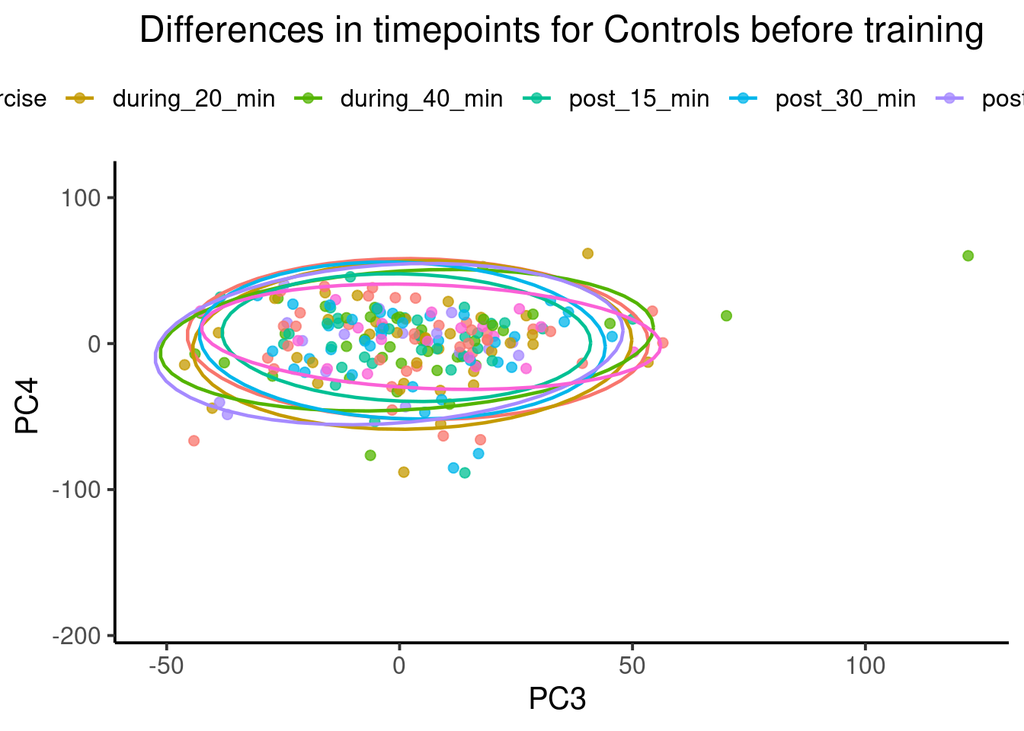

```r
var_exp <- norm_rnaseq_data[['blood_data']][["explained_var"]]*100

ggplot(data=blood_pcas[blood_pcas$randomGroupCode == 'ADUControl' & blood_pcas$pre_or_post_visit == 'ADU_BAS',], aes_string(x='PC3', y='PC4',color = 'Timepoint', group='Timepoint')) +
  geom_point(size=2, alpha=0.75) +
  stat_ellipse(size=0.8, type='t') +
  ylim(c(-190, 110)) +
  guides(color=guide_legend(nrow=1, byrow=TRUE)) +
  theme_classic(base_size = 15) +
  labs(color=var, title='Differences in timepoints for Controls before training', x=paste('PC3 '), y=paste('PC4 ')) +
  theme(legend.position="top", legend.title=element_blank(), plot.title = element_text(hjust = 0.5))
```

Checking if Pre exercise timepoints are different for Controls before and after 12 week training period

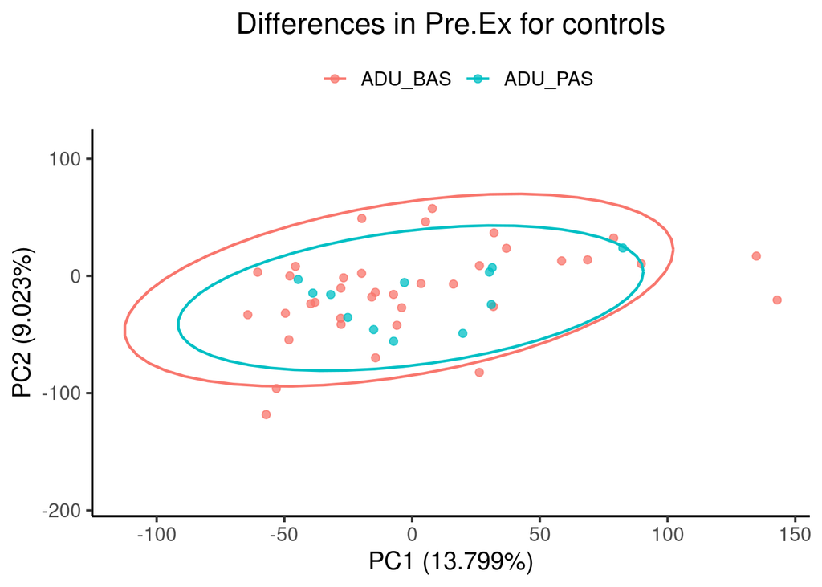

```r
var_exp <- norm_rnaseq_data[['blood_data']][["explained_var"]]*100

ggplot(data=blood_pcas[blood_pcas$randomGroupCode == 'ADUControl' & blood_pcas$Timepoint == 'pre_exercise',], aes_string(x='PC1', y='PC2',color = 'pre_or_post_visit', group='pre_or_post_visit')) +
  geom_point(size=2, alpha=0.75) +
  stat_ellipse(size=0.8, type='t') +
  ylim(c(-190, 110)) +
  guides(color=guide_legend(nrow=1, byrow=TRUE)) +
  theme_classic(base_size = 15) +
  labs(color=var, title='Differences in Pre.Ex for controls', x=paste('PC1 ', '(', var_exp[1], '%)', sep=''), y=paste('PC2 ', '(', var_exp[2], '%)', sep='')) +
  theme(legend.position="top", legend.title=element_blank(), plot.title = element_text(hjust = 0.5))
```

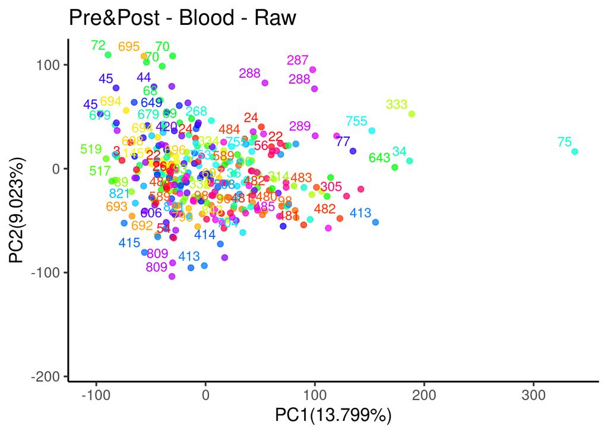

```r
blood_pcas <- blood_pcas %>%
  dplyr::group_by(participant_id, Timepoint) %>%
  dplyr::mutate(duplicate_group = if (n() > 1) cur_group_id() else NA_integer_) %>%
  dplyr::ungroup() %>%
  dplyr::mutate(duplicate_label = ifelse(!is.na(duplicate_group), as.character(duplicate_group), NA))

unique_duplicates <- unique(blood_pcas$duplicate_group[!is.na(blood_pcas$duplicate_group)])
custom_palette <- c("black", setNames(rainbow(length(unique_duplicates)), unique_duplicates))

ggplot(data = blood_pcas, aes(x = PC1, y = PC2, color = as.factor(duplicate_group))) +
  geom_point(size = 2, alpha = 0.75) +
  geom_text(aes(label = duplicate_label), check_overlap = TRUE, hjust = 1.2, vjust = -0.5) +
  ylim(c(-190, 110)) +
  scale_color_manual(values = custom_palette, na.translate = FALSE) +
  theme_classic(base_size = 15) +
  labs(color = "Duplicate Group", title = "Pre&Post - Blood - Raw", x = paste("PC1", "(", var_exp[1], "%)", sep = ""), y = paste("PC2", "(", var_exp[2], "%)", sep = ""))  +
  theme(legend.position = "none")
```

[figure not shown]

```r
muscle_pcas <- muscle_pcas %>%
  dplyr::group_by(participant_id, Timepoint) %>%
  dplyr::mutate(duplicate_group = if (n() > 1) cur_group_id() else NA_integer_) %>%
  dplyr::ungroup() %>%
  dplyr::mutate(duplicate_label = ifelse(!is.na(duplicate_group), as.character(duplicate_group), NA))

unique_duplicates <- unique(muscle_pcas$duplicate_group[!is.na(muscle_pcas$duplicate_group)])
custom_palette <- c("black", setNames(rainbow(length(unique_duplicates)), unique_duplicates))

ggplot(data = muscle_pcas, aes(x = PC1, y = PC2, color = as.factor(duplicate_group))) +
  geom_point(size = 2, alpha = 0.75) +
  geom_text(aes(label = duplicate_label), check_overlap = TRUE, hjust = 1.2, vjust = -0.5) +
  ylim(c(-190, 110)) +
  scale_color_manual(values = custom_palette, na.translate = FALSE) +
  theme_classic(base_size = 15) +
  labs(color = "Duplicate Group", title = "pre&post - Muscle - Raw", x = paste("PC1", "(", var_exp[1], "%)", sep = ""), y = paste("PC2", "(", var_exp[2], "%)", sep = ""))  +
  theme(legend.position = "none")
```

[figure not shown]

```r
adipose_pcas <- adipose_pcas %>%
  dplyr::group_by(participant_id, Timepoint) %>%
  dplyr::mutate(duplicate_group = if (n() > 1) cur_group_id() else NA_integer_) %>%
  dplyr::ungroup() %>%
  dplyr::mutate(duplicate_label = ifelse(!is.na(duplicate_group), as.character(duplicate_group), NA))

unique_duplicates <- unique(adipose_pcas$duplicate_group[!is.na(adipose_pcas$duplicate_group)])
custom_palette <- c("black", setNames(rainbow(length(unique_duplicates)), unique_duplicates))

ggplot(data = adipose_pcas, aes(x = PC1, y = PC2, color = as.factor(duplicate_group))) +
  geom_point(size = 2, alpha = 0.75) +
  geom_text(aes(label = duplicate_label), check_overlap = TRUE, hjust = 1.2, vjust = -0.5) +
  ylim(c(-190, 110)) +
  scale_color_manual(values = custom_palette, na.translate = FALSE) +
  theme_classic(base_size = 15) +
  labs(color = "Duplicate Group", title = "pre&post - adipose - Raw", x = paste("PC1", "(", var_exp[1], "%)", sep = ""), y = paste("PC2", "(", var_exp[2], "%)", sep = ""))  +
  theme(legend.position = "none")
```